# Introduction to Neural Networks: Bank Churn prediction

### Observations:

#### Exited Vs Credit Score

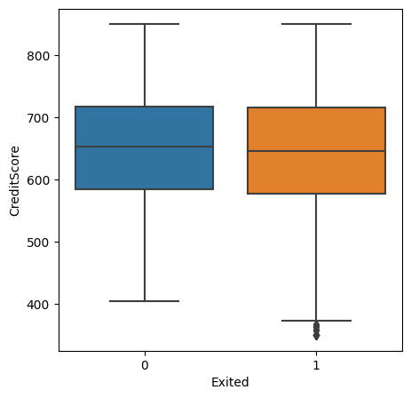

```python
# Plot the boxplot for Exited and Credit Score
plt.figure(figsize=(5,5))
sns.boxplot(data=df, y='CreditScore',x='Exited')
plt.show()
```

### Observations:

- The boxplot shows that almost 75% of customers, regardless of their exit status, have a credit score ranging from about 590 to 710. Nonetheless, there are outliers among the customers who have exited.

#### Exited Vs Age

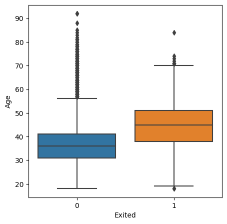

```python
# Plot the boxplot for Exited and Age
plt.figure(figsize=(5,5))
sns.boxplot(data=df, y='Age',x='Exited')
plt.show()
```

### Observations:

- The plot suggests a rising churn rate with age, with 75% of customers who have exited falling within the age range of approximately 39 to 51. In contrast, non-exited customers typically range between 31 and 41 years old. It's noteworthy that there is a notable number of outliers among the non-exited customers and a few outliers among the exited customers.

#### Exited Vs Tenure

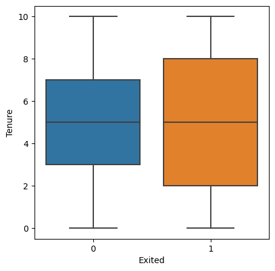

```python
# Plot the boxplot for Exited and Tenure
plt.figure(figsize=(5,5))
sns.boxplot(data=df, y='Tenure',x='Exited')
plt.show()
```

### Observations:

- The boxplot reveals an almost normal distribution of tenure for both exited and non-exited customers. Around 75% of non-exited customers have a tenure ranging from 3 to 7 years with the bank, while 75% of exited customers have a tenure between 2 and 8 years with the bank.

#### Exited Vs Balance

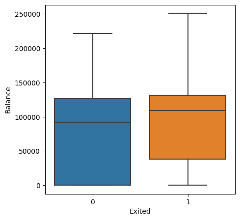

```python
# Plot the boxplot for Exited and Balance
plt.figure(figsize=(5,5))
sns.boxplot(data=df, y='Balance',x='Exited')
plt.show()
```

### Observations:

- The data exposes a pronounced right skewness in the distribution of balances for non-exited customers, with approximately 75% of their balances falling within the range of 0 to 125,000. Conversely, there is a slight right skewness for exited customers, where 75% of their balances are between 50,000 and 130,000. As a result, customers with balances below 50,000 seem to demonstrate a lower likelihood of churning.

#### Exited Vs Number of Products

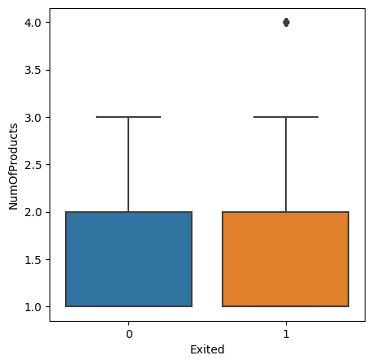

```python
# Plot the boxplot for Exited and Number of products
plt.figure(figsize=(5,5))
sns.boxplot(data=df, y='NumOfProducts',x='Exited')
plt.show()
```

### Observations:

- No discernible distinctions in the churn rate are evident based on the number of products, as approximately 75% of both exited and non-exited customers possess 1 or 2 products. The distributions of both are right-skewed, and there are outliers among the exited customers in this regard.

#### Exited Vs Estimated Salary

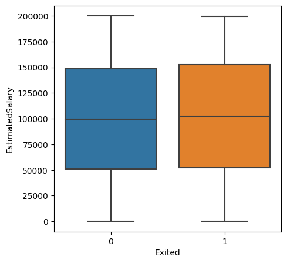

```python
# Plot the boxplot for Exited and Salary
plt.figure(figsize=(5,5))
sns.boxplot(data=df, y='EstimatedSalary',x='Exited')
plt.show()
```

### Observations:

- There are no discernible variations in the churn rate based on customers' salaries, as around 75% of customers, irrespective of their churn status, possess annual incomes ranging from approximately 50,000 to 150,000.

#### Correlation plot

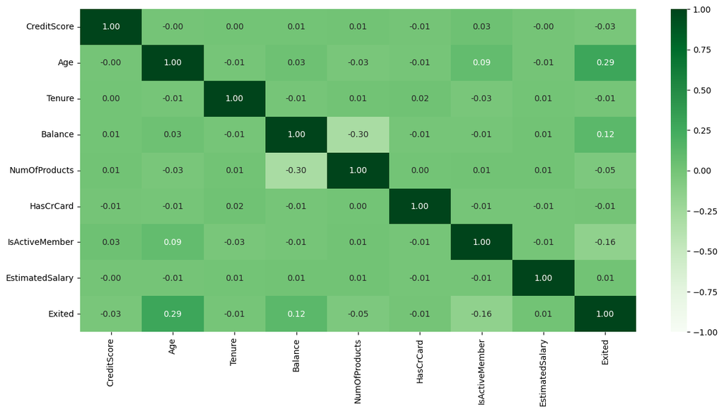

```python
# Display the heatmap of the dataset
plt.figure(figsize=(15, 7))
sns.heatmap(df.corr(), annot=True, vmin=-1, vmax=1, fmt=".2f", cmap="Greens")
plt.show()
```

### Observations:

- There is a moderate positive correlation of 0.29 between Age and the number of customers who have left the bank. In contrast, a comparable negative correlation of -0.3 is noted between account balance and the number of products a customer has purchased through the bank. No significant correlations are evident among other attributes.

## Data Preprocessing

- Missing value treatment
- Feature engineering (if needed)
- Outlier detection and treatment (if needed)
- Preparing data for modeling
- Any other preprocessing steps (if needed)

```python
# Split the data
X = df.drop(['Exited'],axis=1) # drop the dependant feature

y = df[['Exited']] # copy the dependant feature into y
```

```python
# Split the data into  Train and Test
X_large, X_test, y_large, y_test = train_test_split(X,y, test_size = 0.2, random_state = 42,stratify=y,shuffle = True)
```

```python
# Split the train set into the Train and cross validation set
X_train, X_val, y_train, y_val = train_test_split(X_large,y_large, test_size = 0.2, random_state = 42,stratify=y_large, shuffle = True)
```

**Create dummy variables for string type variables**

```python
# Encoding Geography variable
## Encode Geography and Gender in train set
X_train = pd.get_dummies(X_train, columns=["Geography","Gender"],drop_first=True)
## Encode Geography and Gender in test set
X_test = pd.get_dummies(X_test, columns=["Geography","Gender"],drop_first=True)
## Encode Geography and Gender in validation set
X_val = pd.get_dummies(X_val, columns=["Geography","Gender"],drop_first=True)
```

**Normalize the numerical data**

```python
# Function to scale data

def scale_data(data, columns_to_scale):

    sc = StandardScaler()
    data[columns_to_scale] = sc.fit_transform(data[columns_to_scale])
    return data

# Define columns name for scaling
columns_to_scale = ["CreditScore", "Age", "Tenure", "Balance", "EstimatedSalary"]

# Apply scale function to the data for each set
X_train = scale_data(X_train, columns_to_scale)
X_test = scale_data(X_test, columns_to_scale)
X_val = scale_data(X_val, columns_to_scale)
```

## Model Building

### Model Evaluation Criterion

- The model's predictive accuracy is susceptible to errors, particularly in two scenarios:
1. Incorrectly predicting that a customer is leaving when they are not.
2. Incorrectly predicting that a customer is not leaving when they are.
- Determining the criticality of these scenarios is crucial. The more significant concern lies in predicting that a customer is not exiting when, in reality, they are. This situation poses potential financial loss for banks because an erroneous identification prevents the institution from taking necessary measures for these sensitive customers.
- To mitigate this potential loss, it is essential to address the issue of False Negatives. These instances occur when the model fails to identify customers who are actually exiting. To achieve this, the bank should strive to maximize the Recall metric. Recall, representing the ratio of True Positives to the total actual positives, becomes a pivotal factor in minimizing False Negatives.
- By focusing on enhancing Recall, the bank aims to identify as many actual exiting customers as possible, thereby reducing the occurrences of False Negatives. This strategic emphasis on identifying true positives (Class 1) ensures that the bank can take timely actions to retain its customers and mitigate potential financial losses associated with incorrect predictions.

**Create a function for plotting the confusion matrix**

```python
# Create a function for plotting the confusion matrix

def make_confusion_matrix(cf,
                          group_names=None,
                          categories='auto',
                          count=True,
                          percent=True,
                          cbar=True,
                          xyticks=True,
                          xyplotlabels=True,
                          sum_stats=True,
                          figsize=None,
                          cmap='Blues',
                          title=None):
    '''
    This function will make a pretty plot of an sklearn Confusion Matrix cm using a Seaborn heatmap visualization.
    Arguments
    '''


    # CODE TO GENERATE TEXT INSIDE EACH SQUARE
    blanks = ['' for i in range(cf.size)]

    if group_names and len(group_names)==cf.size:
        group_labels = ["{}\n".format(value) for value in group_names]
    else:
        group_labels = blanks

    if count:
        group_counts = ["{0:0.0f}\n".format(value) for value in cf.flatten()]
    else:
        group_counts = blanks

    if percent:
        group_percentages = ["{0:.2%}".format(value) for value in cf.flatten()/np.sum(cf)]
    else:
        group_percentages = blanks

    box_labels = [f"{v1}{v2}{v3}".strip() for v1, v2, v3 in zip(group_labels,group_counts,group_percentages)]
    box_labels = np.asarray(box_labels).reshape(cf.shape[0],cf.shape[1])


    # CODE TO GENERATE SUMMARY STATISTICS & TEXT FOR SUMMARY STATS
    if sum_stats:
        #Accuracy is sum of diagonal divided by total observations
        accuracy  = np.trace(cf) / float(np.sum(cf))

        #if it is a binary confusion matrix, show some more stats
        if len(cf)==2:
            #Metrics for Binary Confusion Matrices
            precision = cf[1,1] / sum(cf[:,1])
            recall    = cf[1,1] / sum(cf[1,:])
            f1_score  = 2*precision*recall / (precision + recall)
            stats_text = "\n\nAccuracy={:0.3f}\nPrecision={:0.3f}\nRecall={:0.3f}\nF1 Score={:0.3f}".format(
                accuracy,precision,recall,f1_score)
        else:
            stats_text = "\n\nAccuracy={:0.3f}".format(accuracy)
    else:
        stats_text = ""


    # SET FIGURE PARAMETERS ACCORDING TO OTHER ARGUMENTS
    if figsize==None:
        #Get default figure size if not set
        figsize = plt.rcParams.get('figure.figsize')

    if xyticks==False:
        #Do not show categories if xyticks is False
        categories=False


    # MAKE THE HEATMAP VISUALIZATION
    plt.figure(figsize=figsize)
    sns.heatmap(cf,annot=box_labels,fmt="",cmap=cmap,cbar=cbar,xticklabels=categories,yticklabels=categories)

    if xyplotlabels:
        plt.ylabel('True label')
        plt.xlabel('Predicted label' + stats_text)
    else:
        plt.xlabel(stats_text)

    if title:
        plt.title(title)
```

### Model Building: Neural Network

```python
# Clear the backend session
keras.backend.clear_session()

# Ensure reproducibility by fixing random number generator seeds
np.random.seed(42)
random.seed(42)
tf.random.set_seed(42)
```

```python
# Initializes the Artificial Neural Network (ANN)
classifier = Sequential()

# Adds the input layer with 64 neurons and ReLU activation function for 11 input variables
classifier.add(Dense(units=64, activation='relu', input_dim=11))

# Adds the 1st hidden layer with 32 neurons and ReLU activation
classifier.add(Dense(units=32, activation='relu'))

# Adds the output layer with one node and sigmoid activation function for probability outcomes
classifier.add(Dense(units=1, activation='sigmoid'))
```

```python
# Compiling the model with Stochastic Gradient Descent (SGD) optimizer,
# binary crossentropy loss, and accuracy as the evaluation metric
classifier.compile(optimizer='sgd', loss='binary_crossentropy', metrics=['accuracy'])
```

```python
## Obtain the summary of the model
classifier.summary()
```

```
Model: "sequential"
_________________________________________________________________
 Layer (type)                Output Shape              Param #
=================================================================
 dense (Dense)               (None, 64)                768

 dense_1 (Dense)             (None, 32)                2080

 dense_2 (Dense)             (None, 1)                 33

=================================================================
Total params: 2,881
Trainable params: 2,881
Non-trainable params: 0
_________________________________________________________________
```

### Observations on Model Architecture:

**Model Structure:**

- The model follows a sequential architecture, where layers are sequentially stacked on top of each other.

**Total Parameters:**

- The model encompasses a total of 2,881 parameters, representing weights and biases learned during training.

**Trainable Parameters:**

- All 2,881 parameters are trainable, signifying their adjustment during training to minimize the model's loss.

**Non-trainable Parameters:**

- No non-trainable parameters are present in this model.

**Layers Information:**

- The model consists of three layers, each labeled as "dense."
  1. **Layer 1 (dense):**
     - Output Shape: (None, 64)
     - Parameters: 768
  2. **Layer 2 (dense_1):**
     - Output Shape: (None, 32)
     - Parameters: 2080
  3. **Layer 3 (dense_2):**
     - Output Shape: (None, 1)
     - Parameters: 33

**Output Shapes:**

- "None" in output shapes indicates variability in the corresponding dimension, influenced by the batch size during training or inference (e.g., (None, 64) signifies 64 features with a flexible number of samples).

**Layer Types:**

- The model employs dense layers, constituting fully connected layers where each neuron in one layer connects to every neuron in the subsequent layer.

**Summary:** In summary, this is a straightforward sequential neural network comprising three fully connected layers. It takes 11 inputs, processes them through these layers, and generates an output. Throughout the training process, the model learns a total of 2,881 parameters to optimize its predictive capabilities.

```python
## Fit the model on train data for 100 epochs
history=classifier.fit(X_train, y_train,
          validation_data=(X_val,y_val),
          epochs=100,
          batch_size=32)
```

### Observations

Performance Metrics:

- Training Loss and Accuracy:
  1. Loss: 0.3276
  2. Accuracy: 86.67%
- These numerical indicators encapsulate the model's efficiency on the training dataset upon the conclusive strides of the 100th epoch.

Validation Performance:

1. Validation Loss: 0.3554
2. Validation Accuracy: 85.37%
- The time taken show the processing time which is trivial 0s formany of the Epochs, while it was 1s for a few.
- These numerical entities delineate the model's adeptness in generalizing to fresh, unexplored data segments within the validation dataset.

In brief, following a century of training epochs:

- The training loss registers at around 0.33, accompanied by a training accuracy of 86.67%.
- Validation loss is documented at around 0.35, with a corresponding validation accuracy of 85.37%.

**In a nutshell:** These statistical values unravel meaningful insights into the model's intricate learning dynamics with the training data and its nuanced prowess in generalizing to novel datasets. The objective remains rooted in achieving a symphony of minimal loss and heightened accuracy across both training and validation sets, emblematic of the model's commendable performance.

**Loss function**

[figure not shown]

```python
# Capturing learning history per epoch
hist  = pd.DataFrame(history.history)
hist['epoch'] = history.epoch

# Plotting accuracy at different epochs
plt.plot(hist['loss'])
plt.plot(hist['val_loss'], color='green')
plt.legend(("train" , "valid") , loc =0)

## Evaluate the model on X_test and y_test
results = classifier.evaluate(X_test, y_test)
```

### Observations

**Confusion matrix**

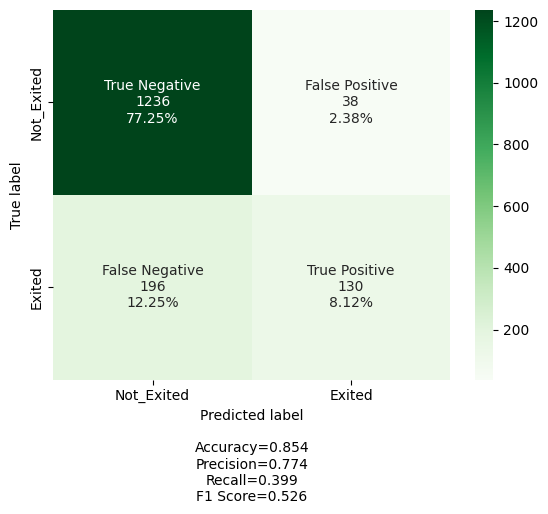

```python
## Obtain the prediction on X_val and obtain the confusion matrix
y_pred1=classifier.predict(X_val)

#Let's predict using default threshold
y_pred1 = (y_pred1 > 0.5)
cm2=confusion_matrix(y_val, y_pred1)
labels = ['True Negative','False Positive','False Negative','True Positive']
categories = [ 'Not_Exited','Exited']
make_confusion_matrix(cm2,
                      group_names=labels,
                      categories=categories,
                      cmap='Greens')
```

### Observations

**Performance Metrics:**

- **Precision:** Precision stands at 77.4%, reflecting the model's capability to precisely identify positive instances.
- **Recall:** With a recall rate of 39.9%, the model displays its effectiveness in identifying relevant instances within the actual positive class.
- **F1 Score:** At 52.6%, the F1 Score accounts for both false positives and false negatives, offering a nuanced assessment.
- **Accuracy:** The model achieves an accuracy of 85.4%, indicating its overall correctness.

**General model Assessment:**

- An accuracy of 85.4% showcases the model's adeptness in accurate class predictions for the majority of instances.
- The precision of 77.4% emphasizes the model's precision in identifying positive cases.
- However, a recall rate of 39.9% suggests a notable portion of actual positive instances being missed by the model.
- The F1 Score, considering both precision and recall, provides a balanced metric, measuring at 52.6%.

**In summary**, while the model demonstrates strong overall accuracy and precision, attention to improving recall is essential for a more comprehensive and balanced performance. With an interest in maximizing recall, the model aims to reduce false negatives. This focus becomes crucial in scenarios where the cost of missing positive instances is high, prioritizing the identification of true positives.

### Model Building: Neural Network model with Adam Optimizer

```python
backend.clear_session()

#Fixing the seed for random number generators so that we can ensure we receive the same output everytime
np.random.seed(2)
random.seed(2)
tf.random.set_seed(2)
```

```python
# Build a function to create a model

def create_custom_model():
    # Initializing the neural network
    model = Sequential()

    # Add the input layer with 64 neurons and relu as activation function
    model.add(Dense(64, activation='relu', input_dim = X_train.shape[1]))

    # Add the first hidden layer with 32 neurons with relu as activation functions
    model.add(Dense(32, activation='relu'))

    # Add the output layer with Sigmoid Activation
    model.add(Dense(1, activation='sigmoid'))

    # Initialize the model with Adam Optimizer
    optimizer = tf.keras.optimizers.Adam(learning_rate=0.001)

    # Compile the model with binary cross-entropy as the loss function and accuracy as metrics
    model.compile(loss='binary_crossentropy', optimizer=optimizer, metrics=['accuracy'])

    return model
```

```python
model=create_custom_model()
model.summary()
```

```
Model: "sequential"
_________________________________________________________________
 Layer (type)                Output Shape              Param #
=================================================================
 dense (Dense)               (None, 64)                768

 dense_1 (Dense)             (None, 32)                2080

 dense_2 (Dense)             (None, 1)                 33

=================================================================
Total params: 2,881
Trainable params: 2,881
Non-trainable params: 0
_________________________________________________________________
```

### Note

- Much like its predecessor, this model is a straightforward sequential neural network comprising three fully connected layers. It accepts input, navigates it through these layers, and generates an output. Throughout the training process, the model acquires knowledge of a cumulative 2,881 parameters.

```python
# Fit the model on train data
history = model.fit(X_train,y_train,batch_size=32,validation_data=(X_val,y_val),epochs=100,verbose=1)
```

### Note

- Following 100 epochs of training, the training process yields a loss of 0.2511 and an accuracy of 89.59%. Simultaneously, the validation phase results in a loss of 0.4101 and an accuracy of 83.44%. These metrics offer valuable perspectives on the model's learning proficiency with the training data and its ability to generalize to novel data. The aspiration is to achieve minimal loss and maximal accuracy on both the training and validation sets, signifying commendable model performance.

**Loss function**

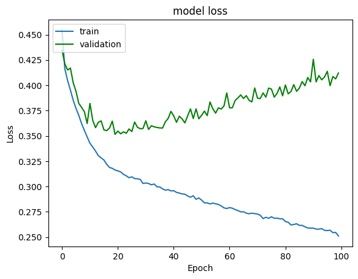

```python
#Plotting Train Loss vs Validation Loss
plt.plot(history.history['loss'])
plt.plot(history.history['val_loss'], color='green')
plt.title('model loss')
plt.ylabel('Loss')
plt.xlabel('Epoch')
plt.legend(['train', 'validation'], loc='upper left')
plt.show()
```

### Observations

- The presented plot unmistakably highlights pronounced overfitting in the model utilizing the Adam optimizer. The abundance of parameters in deep learning models renders them particularly susceptible to overfitting, emphasizing the critical nature of identifying the optimal point to conclude training.
- A highly effective solution to counter this challenge is Early Stopping.
- Early Stopping involves evaluating the model on a distinct validation dataset after each training epoch. Should the model's performance on the validation dataset exhibit signs of deterioration or fail to improve—such as an increase in loss or a decrease in accuracy—the training process is halted after a predefined number of iterations. The model's state at this termination point is then leveraged, ensuring robust generalization performance.

```python
# Importing Callback API
# Define Early Stopping
early_stopping_callback = callbacks.EarlyStopping(monitor='val_loss', min_delta=0.001, patience=5)

# Create the model using the create_custom_model() function
model_with_early_stopping = create_custom_model()

# Train the model on X_train and y_train for 100 epochs, with X_val and y_val as the validation_data
training_history = model_with_early_stopping.fit(
    X_train, y_train,
    batch_size=32,
    epochs=100,
    verbose=1,
    validation_data=(X_val, y_val),
    callbacks=[early_stopping_callback]
)
```

### Observations

- Upon the integration of early stopping, the training process was concluded after the 25th epoch. The training loss stands at 0.3052, accompanied by a training accuracy of 87.22%. Concurrently, the validation phase yielded a loss of 0.3549 and an accuracy of 85.69%. The incorporation of early stopping serves the purpose of mitigating overfitting, guaranteeing that the model attains commendable generalization performance on the validation set.

**Loss function**

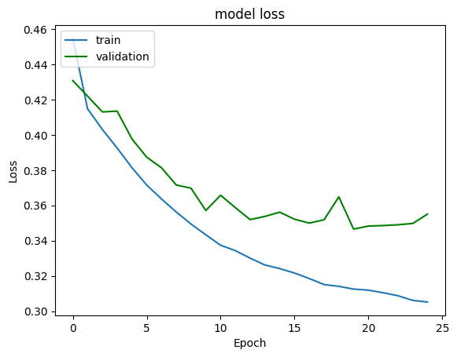

```python
# Plot Train Loss vs Validation Loss
plt.plot(training_history.history['loss'])
plt.plot(training_history.history['val_loss'], color='green')
plt.title('model loss')
plt.ylabel('Loss')
plt.xlabel('Epoch')
plt.legend(['train', 'validation'], loc='upper left')
plt.show()
```

### Observations

The plot above reveals that despite implementing early stopping, there is still evidence of overfitting in the model. This implies that, even with the use of the Adam optimizer and the current number of neurons, the model may not be achieving the best possible generalization.

### Threshold Tuning using ROC-AUC:

Certainly, here's the information presented in a more readable format, suitable for Python text boxes:

```
plaintext
To optimize the trade-off between false positive and true positive rates, the Receiver Operating Characteristic - Area Under the Curve (ROC-AUC) metric becomes a valuable tool. Sensitivity, denoting the true positive rate, and its complement, Specificity, play pivotal roles in this context.

The formulas are articulated as follows:

# Sensitivity
Sensitivity = TruePositive / (TruePositive + FalseNegative)

# Specificity
Specificity = TrueNegative / (FalsePositive + TrueNegative)

Where:

- Sensitivity signifies the True Positive Rate.
- Specificity is equivalent to 1 - False Positive Rate.

The Geometric Mean (G-Mean) emerges as a valuable metric for assessing imbalanced classification, striving to strike a balance between sensitivity and specificity:

# G-Mean
G_Mean = sqrt(Sensitivity * Specificity)

To fine-tune the threshold, experimentation with various thresholds derived from the roc_auc_score() function is essential. The objective is to pinpoint the threshold that maximizes the G-Mean value, thereby achieving an optimal equilibrium between sensitivity and specificity.
```

This formatting should make it more readable within Python text boxes or code environments.

```
Best Threshold=0.186552, G-Mean=0.825
```

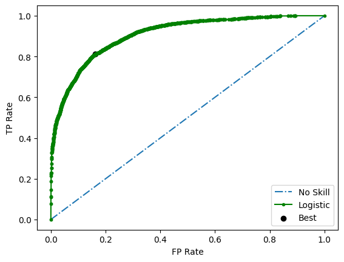

```python
# Predict probabilities
y_probs = model_with_early_stopping.predict(X_train)

# Keep probabilities for the positive outcome only
y_probs = y_probs[:, 0]

# Calculate ROC curves
fpr, tpr, thresholds = roc_curve(y_train, y_probs)

# Calculate the g-mean for each threshold
gmeans = np.sqrt(tpr * (1-fpr))

# Locate the index of the largest g-mean
ix = np.argmax(gmeans)
print('Best Threshold=%f, G-Mean=%.3f' % (thresholds[ix], gmeans[ix]))

# Plot the roc curve for the model
pyplot.plot([0,1], [0,1], linestyle='-.', label='No Skill')
pyplot.plot(fpr, tpr, marker='.', color='green', label='Logistic')
pyplot.scatter(fpr[ix], tpr[ix], marker='o', color='black', label='Best')

# Axis labels
pyplot.xlabel('FP Rate')
pyplot.ylabel('TP Rate')
pyplot.legend()
pyplot.show()
```

### Observations

**Predict the results using the best threshold**

```python
# Predict the results using best as a threshold
y_pred_e=model_with_early_stopping.predict(X_val)
y_pred_e = (y_pred_e > thresholds[ix])
y_pred_e
```

```
array([[ True],
       [False],
       [False],
       ...,
       [False],
       [ True],
       [ True]])
```

**Classification report**

```python
## Obtain the classification report
cr=metrics.classification_report(y_val,y_pred_e)
print(cr)
```

```
              precision    recall  f1-score   support

           0       0.92      0.84      0.88      1274
           1       0.53      0.73      0.61       326

    accuracy                           0.81      1600
   macro avg       0.73      0.78      0.75      1600
weighted avg       0.84      0.81      0.82      1600
```

### Observations

**Confusion matrix**

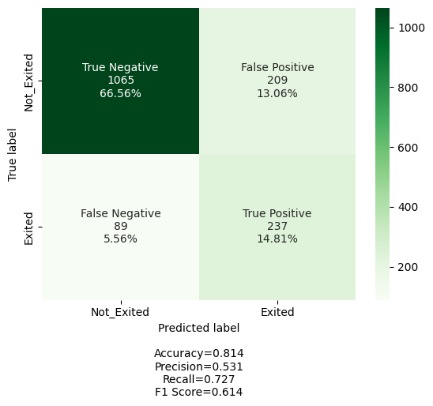

```python
# Complete the code with y_val and y_pred_e to plot the confusion matrix
cm1=confusion_matrix(y_val,y_pred_e)
labels = ['True Negative','False Positive','False Negative','True Positive']
categories = [ 'Not_Exited','Exited']
make_confusion_matrix(cm1,
                      group_names=labels,
                      categories=categories,
                      cmap='Greens')
```

### Observations

- With an emphasis on optimizing recall, the model has showcased a commendable capability to detect positive instances. This becomes especially pivotal when the expense associated with overlooking positive instances is substantial, ensuring a heightened rate of true positives.

**In conclusion**, the model, prioritizing the maximization of recall, strikes a sensible balance between precision and recall, resulting in an overall well-rounded performance.

### Model Improvement: Neural Network model with Dropout

```python
backend.clear_session()
#Fixing the seed for random number generators so that we can ensure we receive the same output everytime
np.random.seed(2)
random.seed(2)
tf.random.set_seed(2)
```

```python
#Initializing the neural network
model_3 = Sequential()

#Adding the input layer with 32 neurons and relu as activation function
model_3.add(Dense(32,activation='relu',input_dim = X_train.shape[1]))

# Add dropout with dropout_rate= 0.2
model_3.add(Dropout(0.2))

# Adding the first hidden layer with 16 neurons with relu as activation functions
model_3.add(Dense(16,activation='relu'))

# Add dropout with dropout_rate= 0.1
model_3.add(Dropout(0.1))
# Adding the second hidden layer with 8 neurons with relu as activation functions
model_3.add(Dense(8,activation='relu'))

# Adding the output layer
model_3.add(Dense(1, activation = 'sigmoid'))
```

```python
# Summary of the model
model_3.summary()
```

```
Model: "sequential"
_________________________________________________________________
 Layer (type)                Output Shape              Param #
=================================================================
 dense (Dense)               (None, 32)                384

 dropout (Dropout)           (None, 32)                0

 dense_1 (Dense)             (None, 16)                528

 dropout_1 (Dropout)         (None, 16)                0

 dense_2 (Dense)             (None, 8)                 136

 dense_3 (Dense)             (None, 1)                 9

=================================================================
Total params: 1,057
Trainable params: 1,057
Non-trainable params: 0
_________________________________________________________________
```

### Observations

- The model encompasses a total of 1,057 parameters, constituting the weights and biases acquired through the training process.
- All 1,057 parameters are designated as trainable, signifying their continuous adjustment and optimization throughout training to minimize the model's loss.
- There are no non-trainable parameters within this model.
- The architecture incorporates dropout layers at positions 2 and 4. Dropout serves as a regularization technique by randomly nullifying a fraction of input units during training, mitigating the risk of overfitting.

**In a nutshell**, this represents a sequential neural network with multiple dense layers and dropout layers. The overall parameter count is relatively modest, indicative of a comparatively simple model.

```python
# Initialize the ANN with Adam optimizer
optimizer = tf.keras.optimizers.Adam(0.001)

# Compile the model with binary cross entropy as loss function and accuracy as metrics
model_3.compile(loss='binary_crossentropy',optimizer=optimizer,metrics=['accuracy'])
```

```python
# ANN with batch_size = 32 and 100 epochs
history_3 = model_3.fit(X_train,y_train,batch_size=32,epochs=100,verbose=1,validation_data=(X_val,y_val),callbacks=[early_stopping_callback])
```

### Observations

- Following the completion of the 38th training epoch, the model exhibits a training loss of 0.3414, accompanied by a training accuracy of 86.22%. Simultaneously, the validation phase yields a loss of 0.3461 and an accuracy of 86.06%. These metrics serve as valuable indicators of the model's learning proficiency with the training data and its ability to generalize effectively to new data.
- The objective is to attain a harmonious balance between minimizing loss and maximizing accuracy on both the training and validation sets. Achieving low loss implies that the model is effectively reducing errors during the training process, while high accuracy signifies its capability to make accurate predictions. Extending this performance to the validation set is essential, ensuring the model's effectiveness in handling unseen data.
- In essence, the reported metrics at the 38th epoch contribute to our understanding of the model's ongoing development and its potential to generalize well beyond the training dataset. The pursuit of simultaneously low loss and high accuracy underscores the overarching goal of establishing a well-performing model.

**Loss function**

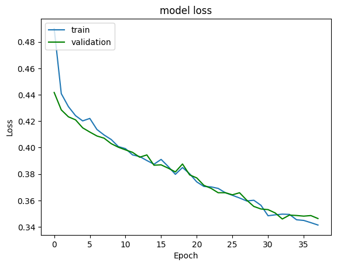

```python
# Complete the code to plot the Train Loss and Validation Loss
plt.plot(history_3.history['loss'])
plt.plot(history_3.history['val_loss'], color='green')
plt.title('model loss')
plt.ylabel('Loss')
plt.xlabel('Epoch')
plt.legend(['train', 'validation'], loc='upper left')
plt.show()
```

### Observations

- The visual representation reveals a continual decline in both training and validation loss with increasing epochs. This consistent downward trend suggests the model's strong generalization capabilities, showcasing its ability to perform well on both the training and validation datasets. Notably, the absence of distinct signs of overfitting or underfitting is indicative of the model's resilience and adaptability to varying data patterns throughout the training process.
- The observed coherence between the decreasing loss curves for both training and validation sets implies that the model is effectively learning and adapting its parameters without exhibiting tendencies toward memorizing the training data (overfitting) or oversimplifying the patterns (underfitting). This visual evidence reinforces the model's stability and robustness, aligning with the overarching objective of achieving optimal performance across diverse datasets.

```
Best Threshold=0.197877, G-Mean=0.810
```

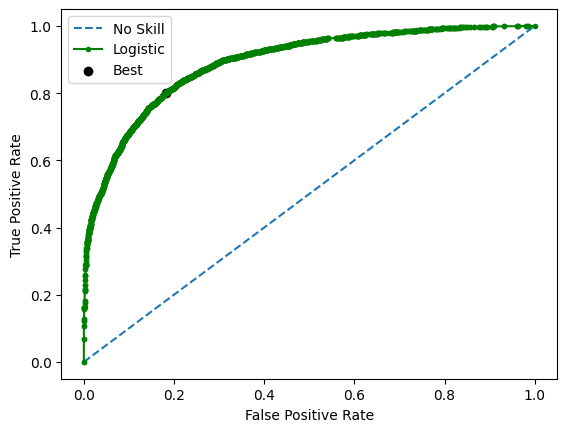

```python
# predict probabilities
yhat = model_3.predict(X_train)
# keep probabilities for the positive outcome only
yhat = yhat[:, 0]
# calculate roc curves
fpr, tpr, thresholds = roc_curve(y_train, yhat)
# calculate the g-mean for each threshold
gmeans = np.sqrt(tpr * (1-fpr))
# locate the index of the largest g-mean
ix = np.argmax(gmeans)
print('Best Threshold=%f, G-Mean=%.3f' % (thresholds[ix], gmeans[ix]))
# plot the roc curve for the model
pyplot.plot([0,1], [0,1], linestyle='--', label='No Skill')
pyplot.plot(fpr, tpr, marker='.', color='green', label='Logistic')
pyplot.scatter(fpr[ix], tpr[ix], marker='o', color='black', label='Best')
# axis labels
pyplot.xlabel('False Positive Rate')
pyplot.ylabel('True Positive Rate')
pyplot.legend()
# show the plot
pyplot.show()
```

### Observations

**Predict the results using the best threshold**

```python
#Predicting the results using best as a threshold
y_pred_e=model_3.predict(X_val)
y_pred_3 = (y_pred_e > thresholds[ix])
y_pred_3
```

```
array([[ True],
       [False],
       [False],
       ...,
       [False],
       [ True],
       [ True]])
```

**Classification report**

```python
# Obtain the classification report
cr=metrics.classification_report(y_val,y_pred_3)
print(cr)
```

```
              precision    recall  f1-score   support

           0       0.92      0.81      0.86      1274
           1       0.50      0.74      0.60       326

    accuracy                           0.80      1600
   macro avg       0.71      0.78      0.73      1600
weighted avg       0.84      0.80      0.81      1600
```

### Observations

- The model exhibits robust precision for class 0 and acceptable precision for class 1, showcasing its ability to make accurate positive and negative predictions. While achieving commendable recall for class 0, the model shows a comparatively lower recall for class 1. The F1-scores contribute to a balanced assessment of the model's performance, and the macro and weighted averages provide a holistic overview. Notably, the introduction of Dropout in the model has led to a slight improvement in recall for class 1 compared to the previous model without Dropout, suggesting that Dropout has positively influenced the model's ability to capture instances of class 1.

**Confusion report**

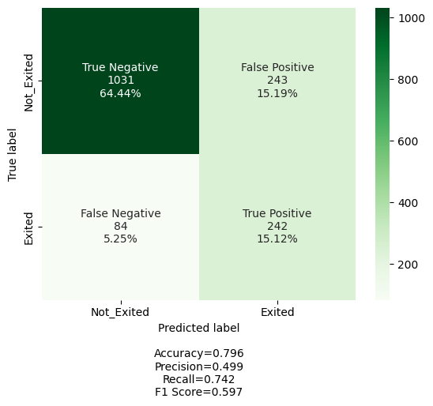

```python
# Obtain the confusion matrix

cm1=confusion_matrix(y_val, y_pred_3)
labels = ['True Negative','False Positive','False Negative','True Positive']
categories = [ 'Not_Exited','Exited']
make_confusion_matrix(cm1,
                      group_names=labels,
                      categories=categories,
                      cmap='Greens')
```

### Observations

- The model is strategically designed with an emphasis on maximizing recall, and as a result, it strikes a judicious trade-off between precision and recall, culminating in an overall well-balanced performance. This deliberate focus on recall aligns with the objective of capturing a higher proportion of true positive instances, which is particularly advantageous when the consequences of missing positive cases are significant. Notably, in comparison to the previous model that lacked Dropout layers, the current model exhibits a slight but noteworthy improvement in recall. This improvement indicates that the incorporation of Dropout layers has played a beneficial role in enhancing the model's generalization capability, especially in recognizing instances belonging to class 1. The utilization of Dropout has contributed to the creation of a more resilient and broadly applicable model, as evidenced by the observed increase in recall.

### Model Improvement: Neural Network model with Hyperparameter tuning

```python
backend.clear_session()
#Fixing the seed for random number generators so that we can ensure we receive the same output everytime
np.random.seed(2)
random.seed(2)
tf.random.set_seed(2)
```

```python
def create_model_v2(dropout_rate=0.1,lr=0.001,layer_1=64,layer_2=32):
    np.random.seed(1337)

    #Initializing the neural network
    model = Sequential()

    # This adds the input layer (by specifying input dimension)
    model.add(Dense(layer_1,activation='relu',input_dim = X_train.shape[1]))

    ## Adding dropout with dropout rate=0.5
    model.add(Dropout(0.5))

    ## Adding the hidden layer
    model.add(Dense(layer_2,activation='relu'))

    ## Adding the output layer
    # We use the sigmoid because we want probability outcomes
    model.add(Dense(1, activation='sigmoid'))

    # Adding Adam initializer
    optimizer = tf.keras.optimizers.Adam(learning_rate=lr)

    ## Compile the model using binary_crossentropy as loss
    model.compile(optimizer = optimizer,loss = 'binary_crossentropy', metrics = ['accuracy'])
    return model
```

**Using Grid search**

```python
## Calling the create_model_v2 function in KerasClassifier
keras_estimator = KerasClassifier(build_fn=create_model_v2, verbose=1)
```

```python
# define the grid search parameters
param_grid = {
    'batch_size':[40, 64, 128],
    "lr":[0.01,0.001,0.1]}


kfold_splits = 3
# Defining keras_estimator as estimator.
grid = GridSearchCV(estimator=keras_estimator,
                    verbose=1,
                    cv=kfold_splits,
                    param_grid=param_grid,n_jobs=-1)
```

```python
## Fit the model on train data and use X_val and y_val as validation data
grid_result = grid.fit(X_train, y_train,validation_data = (X_val,y_val),verbose=1)

# Summarize results
print("Best: %f using %s" % (grid_result.best_score_, grid_result.best_params_))
# Printing mean
means = grid_result.cv_results_['mean_test_score']
# Printing standard deviation
stds = grid_result.cv_results_['std_test_score']
# Printing best parameters
params = grid_result.cv_results_['params']
```

```
Fitting 3 folds for each of 9 candidates, totalling 27 fits
Best: 0.815468 using {'batch_size': 64, 'lr': 0.01}
```

### Observations

**Creating the final model with the obtained configuration after hyperparameter tuning**

```python
# Creating the model
estimator_v2=create_model_v2(lr=grid_result.best_params_['lr'])
# Printing model summary
estimator_v2.summary()
```

```
Model: "sequential_1"
_________________________________________________________________
 Layer (type)                Output Shape              Param #
=================================================================
 dense_3 (Dense)             (None, 64)                768

 dropout_1 (Dropout)         (None, 64)                0

 dense_4 (Dense)             (None, 32)                2080

 dense_5 (Dense)             (None, 1)                 33

=================================================================
Total params: 2,881
Trainable params: 2,881
Non-trainable params: 0
_________________________________________________________________
```

### Observations

```python
# Fit the model on train data abd train the model with best batch_size obtained from hyperparameter tuning
history_h=estimator_v2.fit(X_train, y_train, epochs=100, batch_size = grid_result.best_params_['batch_size'], verbose=1,validation_data=(X_val,y_val))
```